# Задача 24 - множественный регрессионный анализ набора данных ‘Housing’

Антонова Алла, студентка группы БИ-3-23-01

```r
library(readr)
library(ggplot2)
library(corrplot)
library(car)# для VIF
library(lmtest)
library(sandwich)# для робастных ош
library(gridExtra)
```

```r
df <- read_csv("C:/Users/user/Desktop/эконометрика (Наумов В.Н., экзамен)/Экзамен_Антонова/housing_sample.csv")
# Предпросмотр первых 5 строк
cat("Первые 5 строк данных:\n")
```

```
Первые 5 строк данных:
```

```r
print(head(df))
```

| longitude | latitude | housing_median_age | total_rooms | total_bedrooms | population | households | median_income | median_house_value | ocean_INLAND | ocean_ISLAND | ocean_NEAR BAY | ocean_NEAR OCEAN |
| --- | --- | --- | --- | --- | --- | --- | --- | --- | --- | --- | --- | --- |
| -115.40 | 32.86 | 19 | 1087 | 171 | 649 | 173 | 3.3182 | 113800 | 1 | 0 | 0 | 0 |
| -117.88 | 34.13 | 33 | 3713 | 718 | 2106 | 720 | 4.0023 | 185500 | 0 | 0 | 0 | 0 |
| -117.91 | 34.14 | 42 | 2225 | 485 | 1544 | 464 | 2.2442 | 166700 | 1 | 0 | 0 | 0 |
| -117.26 | 33.81 | 22 | 4249 | 922 | 2405 | 846 | 2.1549 | 146500 | 1 | 0 | 0 | 0 |
| -117.05 | 34.89 | 36 | 1199 | 260 | 665 | 229 | 3.7065 | 62000 | 1 | 0 | 0 | 0 |
| -117.47 | 34.12 | 6 | 10565 | 1767 | 5690 | 1555 | 4.1797 | 141000 | 1 | 0 | 0 | 0 |

```r
cat("\nРазмер датасета:\n")
```

```
Размер датасета:
```

```r
print(dim(df))
```

```
[1] 2000   13
```

```r
str(df)
```

```
spc_tbl_ [2,000 × 13] (S3: spec_tbl_df/tbl_df/tbl/data.frame)
 $ longitude         : num [1:2000] -115 -118 -118 -117 -117 ...
 $ latitude          : num [1:2000] 32.9 34.1 34.1 33.8 34.9 ...
 $ housing_median_age: num [1:2000] 19 33 42 22 36 6 10 46 36 33 ...
 $ total_rooms       : num [1:2000] 1087 3713 2225 4249 1199 ...
 $ total_bedrooms    : num [1:2000] 171 718 485 922 260 ...
 $ population        : num [1:2000] 649 2106 1544 2405 665 ...
 $ households        : num [1:2000] 173 720 464 846 229 ...
 $ median_income     : num [1:2000] 3.32 4 2.24 2.15 3.71 ...
 $ median_house_value: num [1:2000] 113800 185500 166700 146500 62000 ...
 $ ocean_INLAND      : num [1:2000] 1 0 1 1 1 1 1 0 0 1 ...
 $ ocean_ISLAND      : num [1:2000] 0 0 0 0 0 0 0 0 0 0 ...
 $ ocean_NEAR BAY    : num [1:2000] 0 0 0 0 0 0 0 1 0 0 ...
 $ ocean_NEAR OCEAN  : num [1:2000] 0 0 0 0 0 0 0 0 0 0 ...
 - attr(*, "spec")=
  .. cols(
  ..   longitude = col_double(),
  ..   latitude = col_double(),
  ..   housing_median_age = col_double(),
  ..   total_rooms = col_double(),
  ..   total_bedrooms = col_double(),
  ..   population = col_double(),
  ..   households = col_double(),
  ..   median_income = col_double(),
  ..   median_house_value = col_double(),
  ..   ocean_INLAND = col_double(),
  ..   ocean_ISLAND = col_double(),
  ..   `ocean_NEAR BAY` = col_double(),
  ..   `ocean_NEAR OCEAN` = col_double()
  .. )
 - attr(*, "problems")=<externalptr>
```

```r
correlation_matrix <- cor(df)
print(round(correlation_matrix, 2))
```

```
                   longitude latitude housing_median_age total_rooms total_bedrooms
longitude               1.00    -0.92              -0.10        0.01           0.03
latitude               -0.92     1.00               0.00       -0.01          -0.04
housing_median_age     -0.10     0.00               1.00       -0.37          -0.31
total_rooms             0.01    -0.01              -0.37        1.00           0.92
total_bedrooms          0.03    -0.04              -0.31        0.92           1.00
population              0.09    -0.10              -0.30        0.85           0.86
households              0.02    -0.05              -0.30        0.92           0.98
median_income          -0.04    -0.06              -0.17        0.20          -0.02
median_house_value     -0.05    -0.14               0.09        0.14           0.06
ocean_INLAND           -0.07     0.37              -0.26        0.02          -0.02
ocean_ISLAND            0.01    -0.02               0.04        0.00           0.00
ocean_NEAR BAY         -0.48     0.36               0.29       -0.02          -0.01
ocean_NEAR OCEAN        0.06    -0.18               0.00        0.01           0.00
                   population households median_income median_house_value ocean_INLAND
longitude                0.09       0.02         -0.04              -0.05        -0.07
latitude                -0.10      -0.05         -0.06              -0.14         0.37
housing_median_age      -0.30      -0.30         -0.17               0.09        -0.26
total_rooms              0.85       0.92          0.20               0.14         0.02
total_bedrooms           0.86       0.98         -0.02               0.06        -0.02
population               1.00       0.89          0.01              -0.02        -0.02
households               0.89       1.00          0.00               0.07        -0.05
median_income            0.01       0.00          1.00               0.69        -0.23
median_house_value      -0.02       0.07          0.69               1.00        -0.48
ocean_INLAND            -0.02      -0.05         -0.23              -0.48         1.00
ocean_ISLAND            -0.01       0.00         -0.01               0.04        -0.02
ocean_NEAR BAY          -0.06       0.00          0.04               0.16        -0.24
ocean_NEAR OCEAN        -0.01       0.00          0.07               0.15        -0.26
                   ocean_ISLAND ocean_NEAR BAY ocean_NEAR OCEAN
longitude                  0.01          -0.48             0.06
latitude                  -0.02           0.36            -0.18
housing_median_age         0.04           0.29             0.00
total_rooms                0.00          -0.02             0.01
total_bedrooms             0.00          -0.01             0.00
population                -0.01          -0.06            -0.01
households                 0.00           0.00             0.00
median_income             -0.01           0.04             0.07
median_house_value         0.04           0.16             0.15
ocean_INLAND              -0.02          -0.24            -0.26
ocean_ISLAND               1.00          -0.01            -0.01
ocean_NEAR BAY            -0.01           1.00            -0.14
ocean_NEAR OCEAN          -0.01          -0.14             1.00
```

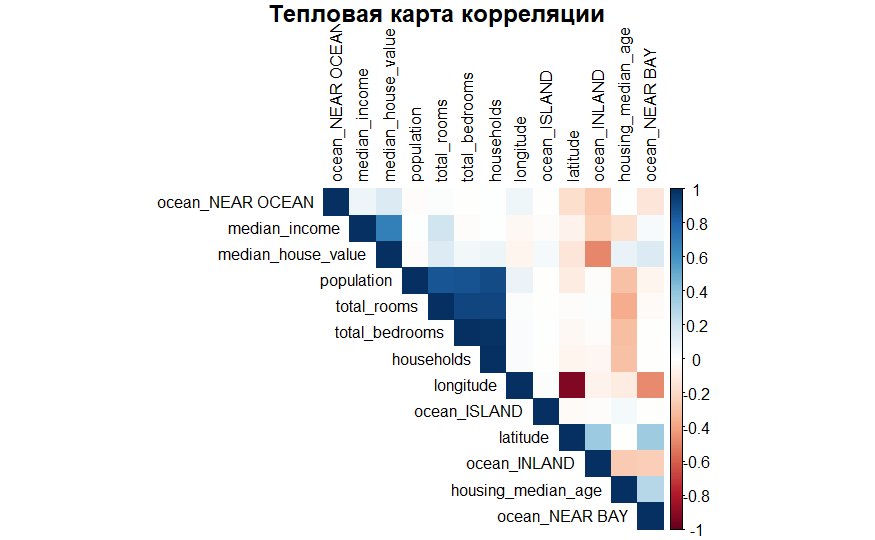

```r
corrplot(correlation_matrix, method = "color", type = "upper",
         order = "hclust", tl.cex = 0.8, tl.col = "black",
         mar = c(0,0,1,0), title = "Тепловая карта корреляции")
```

- Существует сильная отрицательная корреляция между longitude и latitude (r = -0.92) - чем западнее (меньше долгота, longitude), тем севернее (больше широта, latitude)
- total_rooms, total_bedrooms, population, households сильно коррелируют друг с другом (r > 0.85) - чем больше домов, тем больше население, количество комнат, спален и хозяйств:
- Наиболее сильная положительная связь целевой переменной с median_income (r = 0.69) - чем выше доход в районе, тем выше стоимость дома
- Самая высокая отрицательная связь стоимости дома (целевая переменная) с переменной ocean_INLAND (r = -0.48) — действительно, дома в глубине суши дешевле, чем у океана